# The Foundations of Supervised Learning Project

For the Data Science and Business Analytics Post-Graduate Program at the University of Texas in Austin  
by Jacob Fly  
October 13, 2025  
**The Take Away:** The foundations of supervised learning techniques includes methods for forming a linear regression (which is an example of what data scientists call "a model") as well as methods for testing out how well that model represents the data in itself. These techniques are very useful for determining which features of a good or service ought to be given more attention and improved in order to observe the most ideal outcomes.

# Forward: The World Behind The Screens

## Problem Statement: ReCell's Used Phone's Value

What factors influence the predicted price of used devices?

### Business Context

A new IDC (International Data Corporation) forecast predicted that the used phone market would be worth $52.7bn by 2023 with a compound annual growth rate (CAGR) of 13.6% from 2018 to 2023.

Refurbished and used devices are a good deal and are good for the environment.

## Objective

To develop a dynamic pricing strategy for used and refurbished devices  
ReCell, a startup aiming to tap the potential in this market, wants a linear regression model to **predict the price of a used phone/tablet & to identify factors that significantly influence it.**

### Data Description

The data contains the different attributes of used/refurbished phones and tablets. The data was collected in the year 2021.

**Data Dictionary**

- brand_name: Name of manufacturing brand
- os: OS on which the device runs
- screen_size: Size of the screen in cm
- 4g: Whether 4G is available or not
- 5g: Whether 5G is available or not
- main_camera_mp: Resolution of the rear camera in megapixels
- selfie_camera_mp: Resolution of the front camera in megapixels
- int_memory: Amount of internal memory (ROM) in GB
- ram: Amount of RAM in GB
- battery: Energy capacity of the device battery in mAh
- weight: Weight of the device in grams
- release_year: Year when the device model was released
- days_used: Number of days the used/refurbished device has been used
- normalized_new_price: Normalized price of a new device of the same model in euros
- normalized_used_price: Normalized price of the used/refurbished device in euros

# Prologue: The Waves of Delays

EXT. BEACH - SUNRISE

JACK: Say, do you have the time?

JO: No. My phone's dead.

JACK: Have we been out here that long?

JO: Probably not. But I dropped it in the ocean.

JACK: Oh.

JO: Yeah...

JACK: Hey, Jo. Why didn't you call?

JO: What are you talking about?

JACK: All those years ago, you went to New York and I went to Boston, but you never called.

JO: Neither did you.

JACK: I loved you, Jo.

JO: (plays with the sand, then wraps her arms around her knees and stares off into the ocean) ... Tim.

JACK: Oh. Well, does that mean you won't call me tomorrow?

JO: My phone's dead.

JACK: You don't know that.

JO: It's in the ocean.

JACK: Awaiting its fate in the karmic cycle.

JO: Maybe the sharks will call you then?

JACK: Then you can use their old phone if you must.

JO: I do miss talking to you.

JACK: I missed you, Jo.

JO: You did?

Jack: (rests his head on her shoulder) Yeah.

JO: You know, this is a sunrise I’ll remember for the rest of our life.

JACK: I’m sorry we couldn’t make it work. All those years are gone now. They were awful, Jo.

JO: But all and all, we didn’t do too bad at this life thing.

(The silence is filled by the eternal echo of the cosmos' waves upon the shore to which a seagul sings her melody.)

JACK: I guess not...

# Preface: The Sea of The Scene of The Screen

## Importing necessary libraries & data

```python
import numpy as np
import pandas as pd
import matplotlib.pyplot as plt
import seaborn as sns
from sklearn.model_selection import train_test_split
from sklearn.linear_model import LinearRegression
from sklearn.metrics import mean_absolute_error, mean_squared_error, r2_score
import statsmodels.api as sm
from statsmodels.stats.outliers_influence import variance_inflation_factor
```

```python
from google.colab import drive
drive.mount('/content/drive')
data = pd.read_csv('/content/drive/MyDrive/Data Analytics/Supervised Learning/used_device_data.csv')
data.head()
```

|  | brand_name | os | screen_size | 4g | 5g | main_camera_mp | selfie_camera_mp | int_memory | ram | battery | weight | release_year | days_used | normalized_used_price | normalized_new_price |
| --- | --- | --- | --- | --- | --- | --- | --- | --- | --- | --- | --- | --- | --- | --- | --- |
| 0 | Honor | Android | 14.50 | yes | no | 13.0 | 5.0 | 64.0 | 3.0 | 3020.0 | 146.0 | 2020 | 127 | 4.307572 | 4.715100 |
| 1 | Honor | Android | 17.30 | yes | yes | 13.0 | 16.0 | 128.0 | 8.0 | 4300.0 | 213.0 | 2020 | 325 | 5.162097 | 5.519018 |
| 2 | Honor | Android | 16.69 | yes | yes | 13.0 | 8.0 | 128.0 | 8.0 | 4200.0 | 213.0 | 2020 | 162 | 5.111084 | 5.884631 |
| 3 | Honor | Android | 25.50 | yes | yes | 13.0 | 8.0 | 64.0 | 6.0 | 7250.0 | 480.0 | 2020 | 345 | 5.135387 | 5.630961 |
| 4 | Honor | Android | 15.32 | yes | no | 13.0 | 8.0 | 64.0 | 3.0 | 5000.0 | 185.0 | 2020 | 293 | 4.389995 | 4.947837 |

## Data Overview: Observations & Sanity checks

```python
rown,coln = data.shape
print("The dataset has",rown,"rows and",coln,"columns.")
```

```
The dataset has 3454 rows and 15 columns.
```

```python
thetypes = data.dtypes
print('The data types of each of the columns include:')
print(thetypes.to_string(header=False))
```

```
The data types of each of the columns include:
brand_name                object
os                        object
screen_size              float64
4g                        object
5g                        object
main_camera_mp           float64
selfie_camera_mp         float64
int_memory               float64
ram                      float64
battery                  float64
weight                   float64
release_year               int64
days_used                  int64
normalized_used_price    float64
normalized_new_price     float64
```

```python
nullers = data.isnull().sum()
print('The null values in each of the columns:')
print(nullers.to_string(header=False))
```

```
The null values in each of the columns:
brand_name                 0
os                         0
screen_size                0
4g                         0
5g                         0
main_camera_mp           179
selfie_camera_mp           2
int_memory                 4
ram                        4
battery                    6
weight                     7
release_year               0
days_used                  0
normalized_used_price      0
normalized_new_price       0
```

```python
data.describe()
```

|  | screen_size | main_camera_mp | selfie_camera_mp | int_memory | ram | battery | weight | release_year | days_used | normalized_used_price | normalized_new_price |
| --- | --- | --- | --- | --- | --- | --- | --- | --- | --- | --- | --- |
| count | 3454.000000 | 3275.000000 | 3452.000000 | 3450.000000 | 3450.000000 | 3448.000000 | 3447.000000 | 3454.000000 | 3454.000000 | 3454.000000 | 3454.000000 |
| mean | 13.713115 | 9.460208 | 6.554229 | 54.573099 | 4.036122 | 3133.402697 | 182.751871 | 2015.965258 | 674.869716 | 4.364712 | 5.233107 |
| std | 3.805280 | 4.815461 | 6.970372 | 84.972371 | 1.365105 | 1299.682844 | 88.413228 | 2.298455 | 248.580166 | 0.588914 | 0.683637 |
| min | 5.080000 | 0.080000 | 0.000000 | 0.010000 | 0.020000 | 500.000000 | 69.000000 | 2013.000000 | 91.000000 | 1.536867 | 2.901422 |
| 25% | 12.700000 | 5.000000 | 2.000000 | 16.000000 | 4.000000 | 2100.000000 | 142.000000 | 2014.000000 | 533.500000 | 4.033931 | 4.790342 |
| 50% | 12.830000 | 8.000000 | 5.000000 | 32.000000 | 4.000000 | 3000.000000 | 160.000000 | 2015.500000 | 690.500000 | 4.405133 | 5.245892 |
| 75% | 15.340000 | 13.000000 | 8.000000 | 64.000000 | 4.000000 | 4000.000000 | 185.000000 | 2018.000000 | 868.750000 | 4.755700 | 5.673718 |
| max | 30.710000 | 48.000000 | 32.000000 | 1024.000000 | 12.000000 | 9720.000000 | 855.000000 | 2020.000000 | 1094.000000 | 6.619433 | 7.847841 |

# ACT I

## Exploratory Data Analysis (EDA)

In my EDA, I was faced with 7 questions, which I have included as comments above my code.

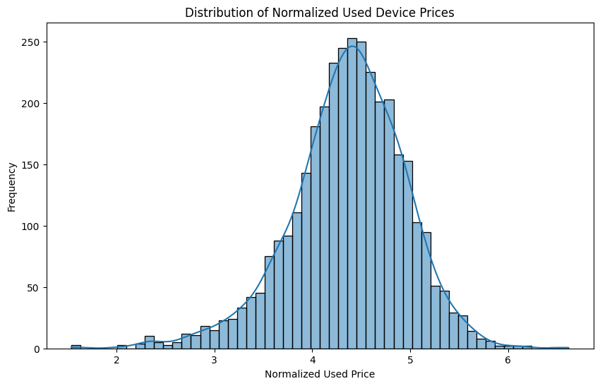

```python
# 1. Distribution of normalized used device prices
plt.figure(figsize=(10, 6))
sns.histplot(data['normalized_used_price'], kde=True)
plt.title('Distribution of Normalized Used Device Prices')
plt.xlabel('Normalized Used Price')
plt.ylabel('Frequency')
plt.show()
```

```
Percentage of Android devices in the used market: 93.05%
```

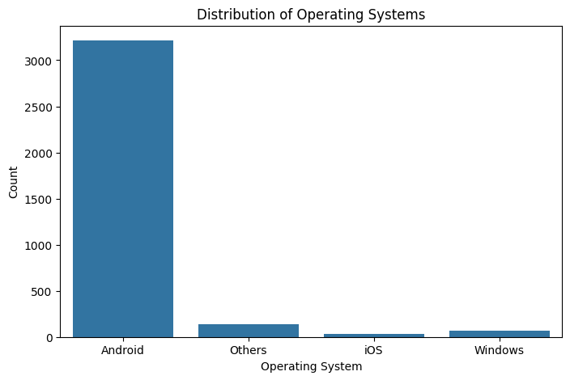

```python
# 2. Percentage of the used device market dominated by Android devices
os_counts = data['os'].value_counts()
android_percentage = (os_counts.get('Android', 0) / os_counts.sum()) * 100
print(f"Percentage of Android devices in the used market: {android_percentage:.2f}%")
plt.figure(figsize=(8, 5))
sns.countplot(data=data, x='os')
plt.title('Distribution of Operating Systems')
plt.xlabel('Operating System')
plt.ylabel('Count')
plt.show()
```

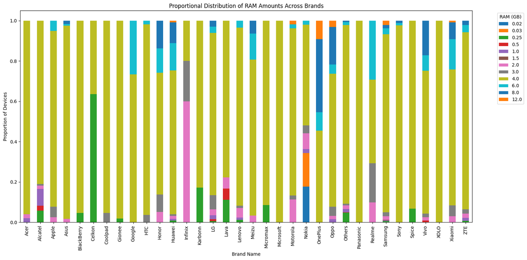

```
Number of devices sold by each brand:
brand_name
Others        502
Samsung       341
Huawei        251
LG            201
Lenovo        171
ZTE           140
Xiaomi        132
Oppo          129
Asus          122
Alcatel       121
Micromax      117
Vivo          117
Honor         116
HTC           110
Nokia         106
Motorola      106
Sony           86
Meizu          62
Gionee         56
Acer           51
XOLO           49
Panasonic      47
Realme         41
Apple          39
Lava           36
Celkon         33
Spice          30
Karbonn        29
BlackBerry     22
OnePlus        22
Microsoft      22
Coolpad        22
Google         15
Infinix        10
Name: count, dtype: int64
```

```python
# 3. The amount of RAM is important for the smooth functioning of a device. How does the amount of RAM vary with the brand?
ram_brand_counts = data.groupby(['brand_name', 'ram']).size().unstack(fill_value=0)
ram_brand_proportions = ram_brand_counts.divide(ram_brand_counts.sum(axis=1), axis=0)

plt.figure(figsize=(16, 8))
ram_brand_proportions.plot(kind='bar', stacked=True, figsize=(16, 8))
plt.title('Proportional Distribution of RAM Amounts Across Brands')
plt.xlabel('Brand Name')
plt.ylabel('Proportion of Devices')
plt.xticks(rotation=90)
plt.legend(title='RAM (GB)', bbox_to_anchor=(1.05, 1), loc='upper left')
plt.tight_layout()
plt.show()

print("\nNumber of devices sold by each brand:")
print(data['brand_name'].value_counts())
```

The most popular brands seem to have success with devices with at least 4GB of ram.

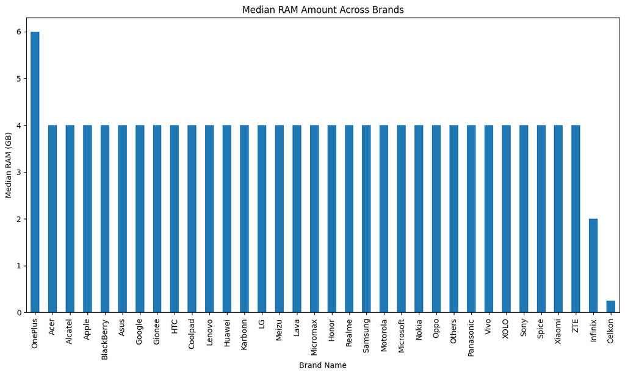

```python
ram_summary = data.groupby('brand_name')['ram'].median().sort_values(ascending=False)

plt.figure(figsize=(14, 7))
ram_summary.plot(kind='bar')
plt.title('Median RAM Amount Across Brands')
plt.xlabel('Brand Name')
plt.ylabel('Median RAM (GB)')
plt.xticks(rotation=90)
plt.show()
```

```
Regression Equation (Weight vs Battery for > 4500 mAh Battery):
------------------------------------------------------------
Weight = -207.2531 + 0.0921 * Battery
------------------------------------------------------------
Regression Accuracy Metrics:
  R-squared: 0.5740
  Mean Absolute Error (MAE): 79.8337
  Mean Squared Error (MSE): 10271.0489
------------------------------------------------------------
```

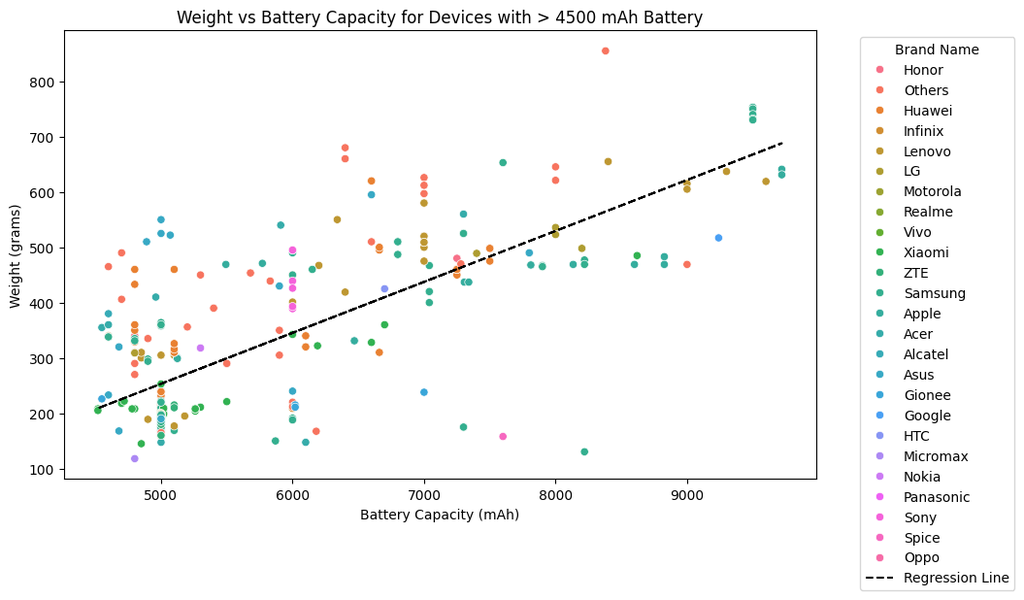

```python
# 4. A large battery often increases a device's weight, making it feel uncomfortable in the hands.
# How does the weight vary for phones and tablets offering large batteries (more than 4500 mAh)?
large_battery_devices = data[data['battery'] > 4500].copy()

# Fit a simple linear regression model
X_battery = large_battery_devices[['battery']]
y_weight = large_battery_devices['weight']

# Add a constant to the independent variable
X_battery = sm.add_constant(X_battery)

# Fit the OLS model
battery_weight_model = sm.OLS(y_weight, X_battery).fit()

# Print the regression equation
print("Regression Equation (Weight vs Battery for > 4500 mAh Battery):")
print("-" * 60)
intercept = battery_weight_model.params['const']
coefficient = battery_weight_model.params['battery']
equation = f"Weight = {intercept:.4f} + {coefficient:.4f} * Battery"
print(equation)
print("-" * 60)

# Calculate and print accuracy metrics
y_pred_weight = battery_weight_model.predict(X_battery)
mae_weight = mean_absolute_error(y_weight, y_pred_weight)
mse_weight = mean_squared_error(y_weight, y_pred_weight)
r2_weight = r2_score(y_weight, y_pred_weight)

print(f"Regression Accuracy Metrics:")
print(f"  R-squared: {r2_weight:.4f}")
print(f"  Mean Absolute Error (MAE): {mae_weight:.4f}")
print(f"  Mean Squared Error (MSE): {mse_weight:.4f}")
print("-" * 60)

plt.figure(figsize=(10, 6))
sns.scatterplot(data=large_battery_devices, x='battery', y='weight', hue='brand_name')

# Plot the regression line
plt.plot(large_battery_devices['battery'], y_pred_weight, color='black', linestyle='--', label='Regression Line')

plt.title('Weight vs Battery Capacity for Devices with > 4500 mAh Battery')
plt.xlabel('Battery Capacity (mAh)')
plt.ylabel('Weight (grams)')
plt.legend(title='Brand Name', bbox_to_anchor=(1.05, 1), loc='upper left')
plt.show()
```

```
Number of devices with screen size > 6 inches by brand:
brand_name
Huawei       149
Samsung      119
Others        99
Vivo          80
Honor         72
Oppo          70
Lenovo        69
Xiaomi        69
LG            59
Motorola      42
Asus          41
Realme        40
Alcatel       26
Apple         24
Acer          19
Meizu         17
ZTE           17
OnePlus       16
Nokia         15
Sony          12
Infinix       10
HTC            7
Micromax       7
Google         4
Coolpad        3
Gionee         3
XOLO           3
Panasonic      2
Karbonn        2
Spice          2
Microsoft      1
Name: count, dtype: int64
```

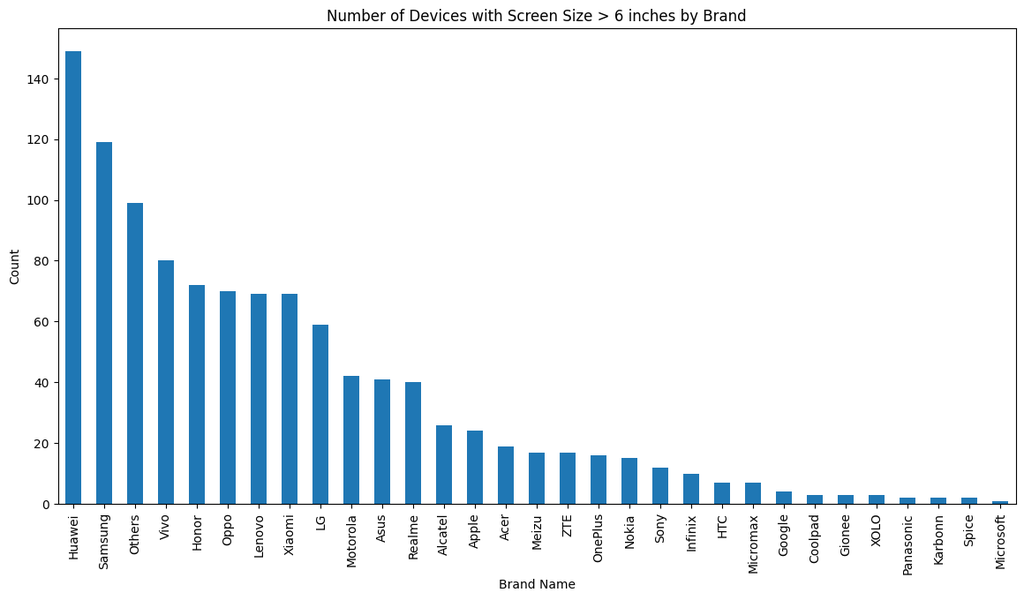

```python
# 5. Bigger screens are desirable for entertainment purposes as they offer a better viewing experience.
# How many phones and tablets are available across different brands with a screen size larger than 6 inches?
large_screen_devices = data[data['screen_size'] > 6 * 2.54] # Convert inches to cm
large_screen_counts = large_screen_devices['brand_name'].value_counts()

print("Number of devices with screen size > 6 inches by brand:")
print(large_screen_counts)

plt.figure(figsize=(14, 7))
large_screen_counts.plot(kind='bar')
plt.title('Number of Devices with Screen Size > 6 inches by Brand')
plt.xlabel('Brand Name')
plt.ylabel('Count')
plt.xticks(rotation=90)
plt.show()
```

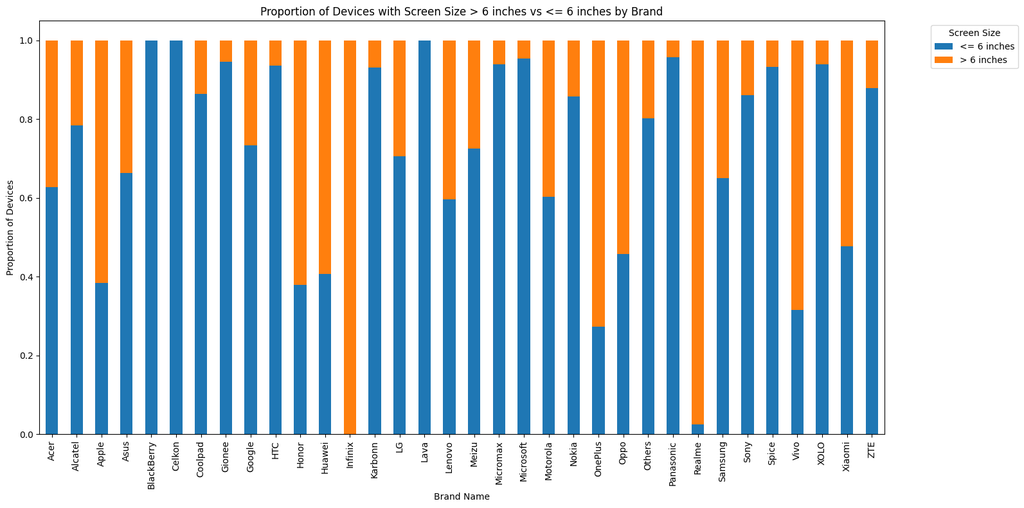

```python
# Create a new column to categorize screen size
data['screen_size_category'] = data['screen_size'].apply(lambda x: '> 6 inches' if x > 6 * 2.54 else '<= 6 inches')

# Group by brand and screen size category and count
screen_size_counts = data.groupby(['brand_name', 'screen_size_category']).size().unstack(fill_value=0)

# Calculate proportions for stacking
screen_size_proportions = screen_size_counts.divide(screen_size_counts.sum(axis=1), axis=0)

# Plot the stacked bar chart
plt.figure(figsize=(16, 8))
screen_size_proportions.plot(kind='bar', stacked=True, figsize=(16, 8))
plt.title('Proportion of Devices with Screen Size > 6 inches vs <= 6 inches by Brand')
plt.xlabel('Brand Name')
plt.ylabel('Proportion of Devices')
plt.xticks(rotation=90)
plt.legend(title='Screen Size', bbox_to_anchor=(1.05, 1), loc='upper left')
plt.tight_layout()
plt.show()

# Drop the temporary screen_size_category column
data = data.drop('screen_size_category', axis=1)
```

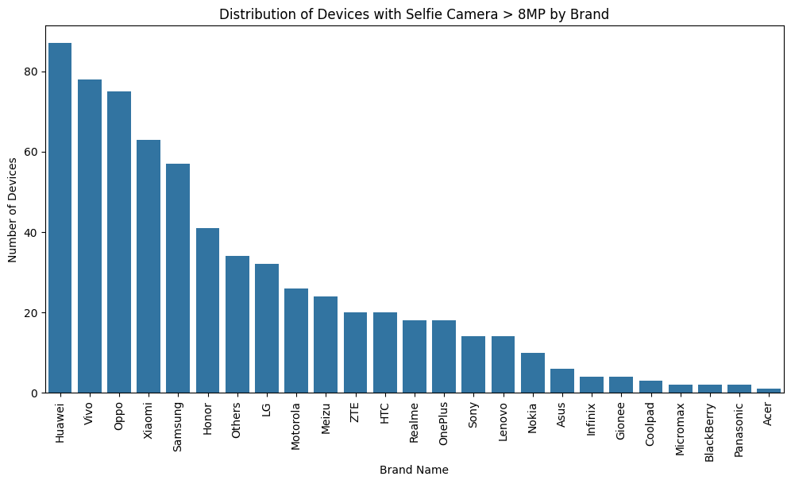

```python
# 6. Distribution of devices offering greater than 8MP selfie cameras across brands
high_selfie_camera_devices = data[data['selfie_camera_mp'] > 8]

plt.figure(figsize=(12, 6))
sns.countplot(x='brand_name', data=high_selfie_camera_devices, order = high_selfie_camera_devices['brand_name'].value_counts().index)
plt.title('Distribution of Devices with Selfie Camera > 8MP by Brand')
plt.xlabel('Brand Name')
plt.ylabel('Number of Devices')
plt.xticks(rotation=90)
plt.show()
```

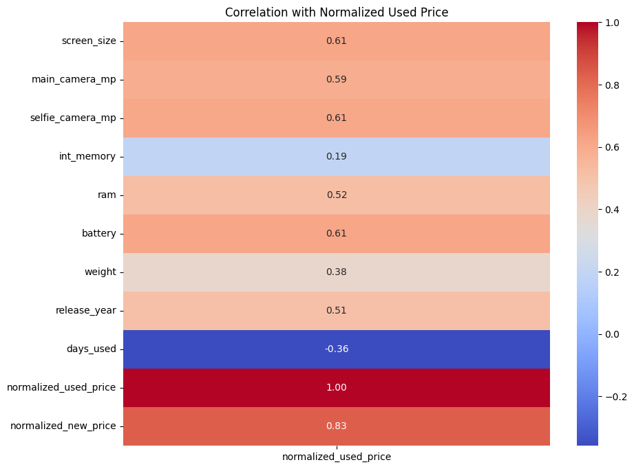

```python
# 7. Which attributes are highly correlated with the normalized price of a used device?
correlation_matrix = data.corr(numeric_only=True)

plt.figure(figsize=(10, 8))
sns.heatmap(correlation_matrix[['normalized_used_price']], annot=True, cmap='coolwarm', fmt=".2f")
plt.title('Correlation with Normalized Used Price')
plt.show()
```

It seems that the battery quality, camera capability, and screen size are the most correlated to the price, and these factors might also affect the price of new devices, but the price of new devices shows the greatest correlation to the price of the used devices.

## Bivariate Analysis

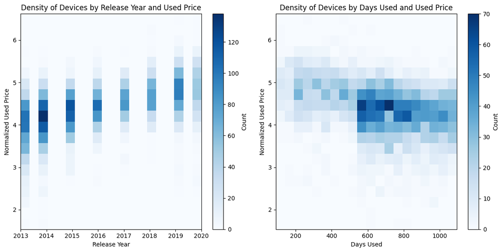

```python
# 2D Histogram: Normalized Used Price vs Release Year
plt.figure(figsize=(12, 6))
plt.subplot(1, 2, 1)
plt.hist2d(data['release_year'], data['normalized_used_price'], bins=20, cmap='Blues')
plt.colorbar(label='Count')
plt.title('Density of Devices by Release Year and Used Price')
plt.xlabel('Release Year')
plt.ylabel('Normalized Used Price')

# 2D Histogram: Normalized Used Price vs Days Used
plt.subplot(1, 2, 2)
plt.hist2d(data['days_used'], data['normalized_used_price'], bins=20, cmap='Blues')
plt.colorbar(label='Count')
plt.title('Density of Devices by Days Used and Used Price')
plt.xlabel('Days Used')
plt.ylabel('Normalized Used Price')

plt.tight_layout()
plt.show()
```

It seems that people are willing to pay more for a newer phone that has been used for a fewer number of days.

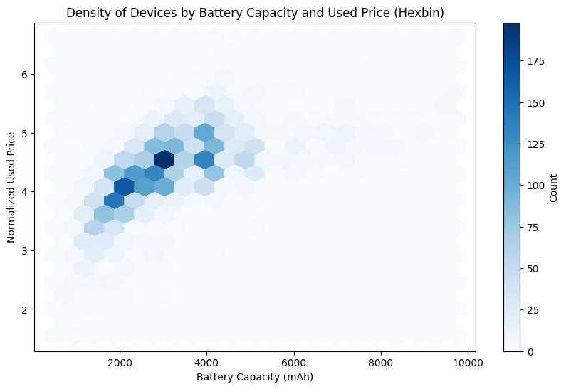

```python
# Graph the correlation between battery and used price using a hexbin plot
plt.figure(figsize=(10, 6))
plt.hexbin(data['battery'], data['normalized_used_price'], gridsize=20, cmap='Blues')
plt.colorbar(label='Count')
plt.title('Density of Devices by Battery Capacity and Used Price (Hexbin)')
plt.xlabel('Battery Capacity (mAh)')
plt.ylabel('Normalized Used Price')
plt.show()
```

## Data preprocessing

First, I'll see where the null values lie.

```python
print(data.isnull().sum())
```

```
brand_name                 0
os                         0
screen_size                0
4g                         0
5g                         0
main_camera_mp           179
selfie_camera_mp           2
int_memory                 4
ram                        4
battery                    6
weight                     7
release_year               0
days_used                  0
normalized_used_price      0
normalized_new_price       0
dtype: int64
```

```python
print(data.isnull().sum())
```

```
brand_name                 0
os                         0
screen_size                0
4g                         0
5g                         0
main_camera_mp           179
selfie_camera_mp           2
int_memory                 4
ram                        4
battery                    6
weight                     7
release_year               0
days_used                  0
normalized_used_price      0
normalized_new_price       0
dtype: int64
```

Then, I'll impute missing values in numerical columns with the median, as the number of missing values is relatively small for these columns.

```python
for col in ['main_camera_mp', 'selfie_camera_mp', 'int_memory', 'ram', 'battery', 'weight']:
    data[col].fillna(data[col].median(), inplace=True)

print(data.isnull().sum())
```

```
brand_name               0
os                       0
screen_size              0
4g                       0
5g                       0
main_camera_mp           0
selfie_camera_mp         0
int_memory               0
ram                      0
battery                  0
weight                   0
release_year             0
days_used                0
normalized_used_price    0
normalized_new_price     0
dtype: int64
```

# ACT II

## Exploratory data analysis (eda) post-preprocessing

Next, to prepare the data for modeling with dummy variables

```python
X = data.drop('normalized_used_price', axis=1)
y = data['normalized_used_price']

X = pd.get_dummies(X, columns=['brand_name', 'os', '4g', '5g'], drop_first=True)

display(X.head())
display(y.head())
```

|  | screen_size | main_camera_mp | selfie_camera_mp | int_memory | ram | battery | weight | release_year | days_used | normalized_new_price | ... | brand_name_Spice | brand_name_Vivo | brand_name_XOLO | brand_name_Xiaomi | brand_name_ZTE | os_Others | os_Windows | os_iOS | 4g_yes | 5g_yes |
| --- | --- | --- | --- | --- | --- | --- | --- | --- | --- | --- | --- | --- | --- | --- | --- | --- | --- | --- | --- | --- | --- |
| 0 | 14.50 | 13.0 | 5.0 | 64.0 | 3.0 | 3020.0 | 146.0 | 2020 | 127 | 4.715100 | ... | False | False | False | False | False | False | False | False | True | False |
| 1 | 17.30 | 13.0 | 16.0 | 128.0 | 8.0 | 4300.0 | 213.0 | 2020 | 325 | 5.519018 | ... | False | False | False | False | False | False | False | False | True | True |
| 2 | 16.69 | 13.0 | 8.0 | 128.0 | 8.0 | 4200.0 | 213.0 | 2020 | 162 | 5.884631 | ... | False | False | False | False | False | False | False | False | True | True |
| 3 | 25.50 | 13.0 | 8.0 | 64.0 | 6.0 | 7250.0 | 480.0 | 2020 | 345 | 5.630961 | ... | False | False | False | False | False | False | False | False | True | True |
| 4 | 15.32 | 13.0 | 8.0 | 64.0 | 3.0 | 5000.0 | 185.0 | 2020 | 293 | 4.947837 | ... | False | False | False | False | False | False | False | False | True | False |

5 rows × 48 columns

|  | normalized_used_price |
| --- | --- |
| 0 | 4.307572 |
| 1 | 5.162097 |
| 2 | 5.111084 |
| 3 | 5.135387 |
| 4 | 4.389995 |

**dtype:** float64

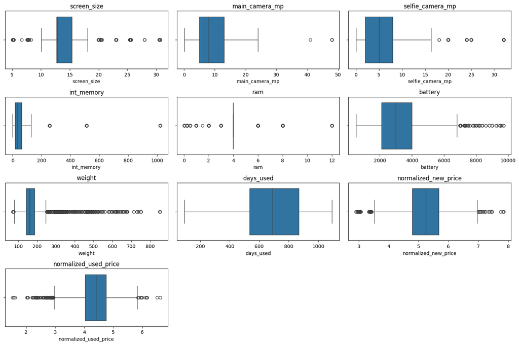

```python
numerical_cols = ['screen_size', 'main_camera_mp', 'selfie_camera_mp', 'int_memory', 'ram', 'battery', 'weight', 'days_used', 'normalized_new_price', 'normalized_used_price']

plt.figure(figsize=(15, 10))
for i, col in enumerate(numerical_cols):
    plt.subplot(4, 3, i + 1)
    sns.boxplot(x=data[col])
    plt.title(col)
plt.tight_layout()
plt.show()
```

There are a lot of outliers. So, I'll cap the outliers in the identified numerical columns using the 1st and 99th percentiles.

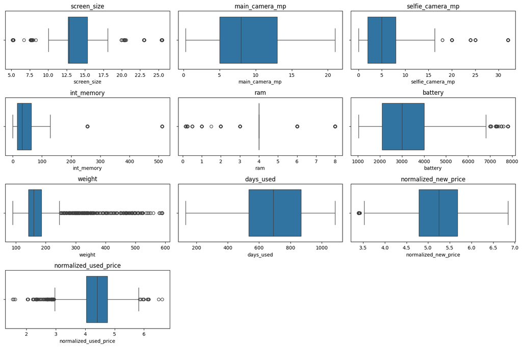

```python
for col in ['screen_size', 'main_camera_mp', 'selfie_camera_mp', 'int_memory', 'ram', 'battery', 'weight', 'days_used', 'normalized_new_price']:
    lower_bound = data[col].quantile(0.01)
    upper_bound = data[col].quantile(0.99)
    data[col] = np.where(data[col] < lower_bound, lower_bound, data[col])
    data[col] = np.where(data[col] > upper_bound, upper_bound, data[col])

plt.figure(figsize=(15, 10))
for i, col in enumerate(numerical_cols):
    plt.subplot(4, 3, i + 1)
    sns.boxplot(x=data[col])
    plt.title(col)
plt.tight_layout()
plt.show()
```

## Data preprocessing

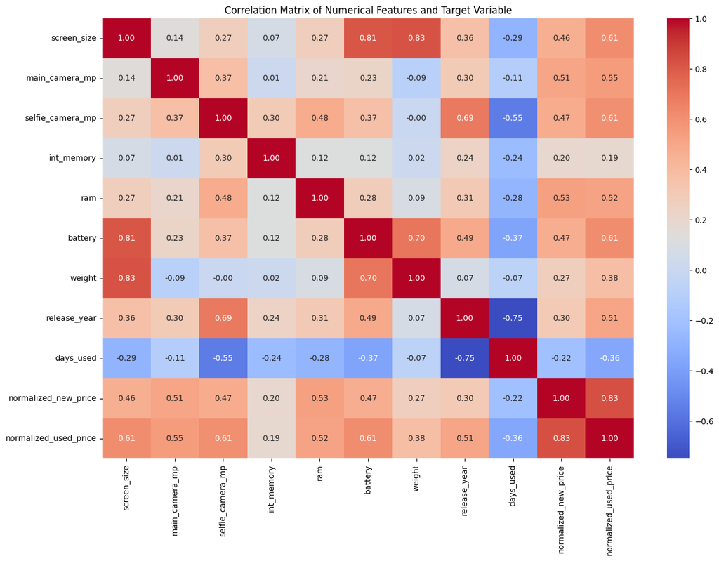

```python
numerical_X = X.select_dtypes(include=np.number)
correlation_matrix = pd.concat([numerical_X, y], axis=1).corr()

plt.figure(figsize=(15, 10))
sns.heatmap(correlation_matrix, annot=True, cmap='coolwarm', fmt=".2f")
plt.title('Correlation Matrix of Numerical Features and Target Variable')
plt.show()
```

What I find most insightful to this heatmap is the correlation between the correlations between various factors and new devices and the correlations between those same factors and used devices.

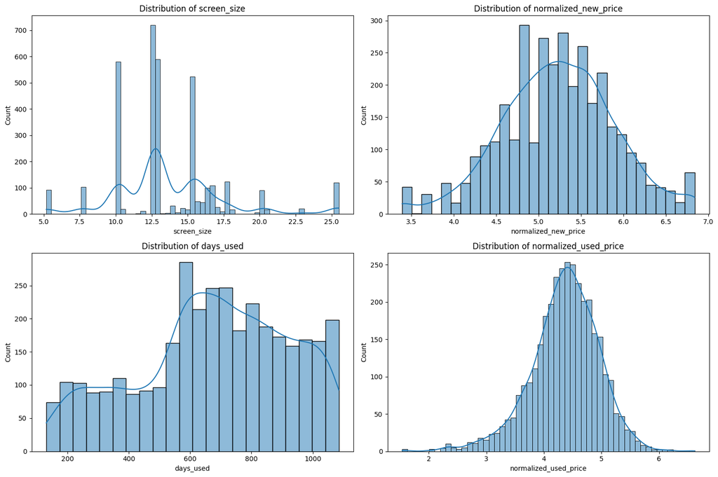

```python
selected_features = ['screen_size', 'normalized_new_price', 'days_used', 'normalized_used_price']

plt.figure(figsize=(15, 10))
for i, col in enumerate(selected_features):
    plt.subplot(2, 2, i + 1)
    sns.histplot(data[col], kde=True)
    plt.title(f'Distribution of {col}')
plt.tight_layout()
plt.show()
```

# ACT II

## Model building

```python
X_train, X_test, y_train, y_test = train_test_split(X, y, test_size=0.2, random_state=42)

lr_model = LinearRegression()
lr_model.fit(X_train, y_train)
```

```
LinearRegression()
```

## Model performance check

```python
y_pred = lr_model.predict(X_test)

mae = mean_absolute_error(y_test, y_pred)
mse = mean_squared_error(y_test, y_pred)
rmse = np.sqrt(mse)
r2 = r2_score(y_test, y_pred)

print(f'Mean Absolute Error (MAE): {mae:.4f}')
print(f'Mean Squared Error (MSE): {mse:.4f}')
print(f'Root Mean Squared Error (RMSE): {rmse:.4f}')
print(f'R-squared (R2) Score: {r2:.4f}')
```

```
Mean Absolute Error (MAE): 0.1844
Mean Squared Error (MSE): 0.0533
Root Mean Squared Error (RMSE): 0.2309
R-squared (R2) Score: 0.8357
```

## Checking linear regression assumptions

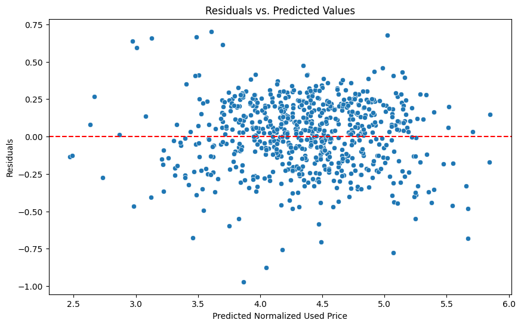

```python
residuals = y_test - y_pred

plt.figure(figsize=(10, 6))
sns.scatterplot(x=y_pred, y=residuals)
plt.axhline(y=0, color='r', linestyle='--')
plt.xlabel('Predicted Normalized Used Price')
plt.ylabel('Residuals')
plt.title('Residuals vs. Predicted Values')
plt.show()
```

Linearity and homoscedasticity are safe assumptions to make because there is an apparent trend that is fairly well balanced.

[figure not shown]

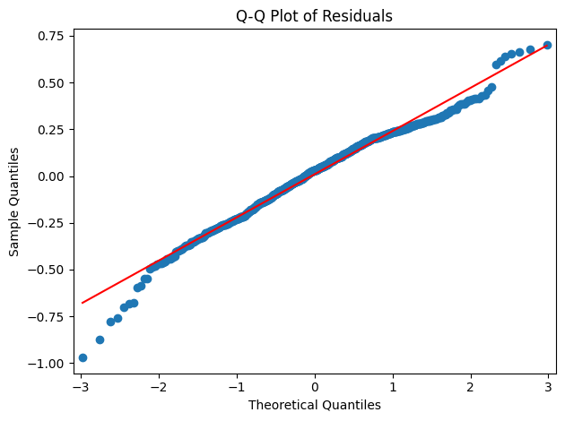

```python
plt.figure(figsize=(12, 6))
plt.subplot(1, 2, 1)
sns.histplot(residuals, kde=True)
plt.title('Distribution of Residuals')
plt.xlabel('Residuals')
plt.ylabel('Frequency')

plt.subplot(1, 2, 2)
sm.qqplot(residuals, line='s')
plt.title('Q-Q Plot of Residuals')

plt.tight_layout()
plt.show()
```

The normality of residuals is shown by the fairly straight line of residuals in this Q-Q plot.

```python
vif_data = pd.DataFrame()
vif_data['feature'] = X_train.columns
vif_data['VIF'] = [variance_inflation_factor(X_train.values.astype(float), i) for i in range(X_train.shape[1])]

display(vif_data.sort_values(by='VIF', ascending=False))
```

|  | feature | VIF |
| --- | --- | --- |
| 7 | release_year | 225.170894 |
| 9 | normalized_new_price | 173.295122 |
| 0 | screen_size | 108.354200 |
| 6 | weight | 32.244509 |
| 5 | battery | 27.871320 |
| 4 | ram | 22.491044 |
| 8 | days_used | 15.835933 |
| 11 | brand_name_Apple | 12.582199 |
| 33 | brand_name_Others | 12.080006 |
| 45 | os_iOS | 11.448696 |
| 1 | main_camera_mp | 10.643261 |
| 36 | brand_name_Samsung | 8.605773 |
| 20 | brand_name_Huawei | 6.783466 |
| 46 | 4g_yes | 6.676546 |
| 23 | brand_name_LG | 5.308772 |
| 25 | brand_name_Lenovo | 4.775278 |
| 2 | selfie_camera_mp | 4.774341 |
| 42 | brand_name_ZTE | 4.247576 |
| 32 | brand_name_Oppo | 4.154198 |
| 41 | brand_name_Xiaomi | 3.974707 |
| 19 | brand_name_Honor | 3.892075 |
| 30 | brand_name_Nokia | 3.776794 |
| 12 | brand_name_Asus | 3.734464 |
| 27 | brand_name_Micromax | 3.729229 |
| 39 | brand_name_Vivo | 3.682208 |
| 10 | brand_name_Alcatel | 3.544503 |
| 18 | brand_name_HTC | 3.426084 |
| 29 | brand_name_Motorola | 3.418479 |
| 37 | brand_name_Sony | 3.078488 |
| 26 | brand_name_Meizu | 2.297962 |
| 40 | brand_name_XOLO | 2.163336 |
| 28 | brand_name_Microsoft | 2.068256 |
| 16 | brand_name_Gionee | 2.066168 |
| 35 | brand_name_Realme | 1.921488 |
| 43 | os_Others | 1.900691 |
| 34 | brand_name_Panasonic | 1.897632 |
| 47 | 5g_yes | 1.881472 |
| 14 | brand_name_Celkon | 1.850994 |
| 3 | int_memory | 1.835327 |
| 24 | brand_name_Lava | 1.799574 |
| 44 | os_Windows | 1.754423 |
| 22 | brand_name_Karbonn | 1.679241 |
| 38 | brand_name_Spice | 1.626815 |
| 15 | brand_name_Coolpad | 1.574653 |
| 13 | brand_name_BlackBerry | 1.560927 |
| 31 | brand_name_OnePlus | 1.557658 |
| 17 | brand_name_Google | 1.354360 |
| 21 | brand_name_Infinix | 1.230695 |

## Final model

```python
X_train = sm.add_constant(X_train)
X_train = X_train.astype(float)
ols_model = sm.OLS(y_train, X_train).fit()
print(ols_model.summary())
```

```
                              OLS Regression Results
=================================================================================
Dep. Variable:     normalized_used_price   R-squared:                       0.847
Model:                               OLS   Adj. R-squared:                  0.844
Method:                    Least Squares   F-statistic:                     313.1
Date:                   Mon, 30 Mar 2026   Prob (F-statistic):               0.00
Time:                           04:44:03   Log-Likelihood:                 115.07
No. Observations:                   2763   AIC:                            -132.1
Df Residuals:                       2714   BIC:                             158.1
Df Model:                             48
Covariance Type:               nonrobust
=========================================================================================
                            coef    std err          t      P>|t|      [0.025      0.975]
-----------------------------------------------------------------------------------------
const                   -52.2895      8.622     -6.065      0.000     -69.196     -35.383
screen_size               0.0281      0.003      8.508      0.000       0.022       0.035
main_camera_mp            0.0213      0.001     15.347      0.000       0.019       0.024
selfie_camera_mp          0.0127      0.001     11.580      0.000       0.011       0.015
int_memory             9.163e-05   5.95e-05      1.541      0.123    -2.5e-05       0.000
ram                       0.0257      0.005      5.176      0.000       0.016       0.035
battery               -1.756e-05   7.05e-06     -2.490      0.013   -3.14e-05   -3.73e-06
weight                    0.0008      0.000      6.645      0.000       0.001       0.001
release_year              0.0266      0.004      6.219      0.000       0.018       0.035
days_used              2.313e-05   2.87e-05      0.805      0.421   -3.32e-05    7.95e-05
normalized_new_price      0.4246      0.012     36.808      0.000       0.402       0.447
brand_name_Alcatel       -0.0702      0.046     -1.526      0.127      -0.160       0.020
brand_name_Apple         -0.0075      0.147     -0.051      0.959      -0.296       0.281
brand_name_Asus           0.0120      0.045      0.263      0.792      -0.077       0.101
brand_name_BlackBerry     0.0230      0.069      0.333      0.739      -0.112       0.158
brand_name_Celkon        -0.1864      0.063     -2.977      0.003      -0.309      -0.064
brand_name_Coolpad        0.0079      0.066      0.121      0.904      -0.121       0.137
brand_name_Gionee        -0.0327      0.055     -0.599      0.549      -0.140       0.074
brand_name_Google        -0.0930      0.079     -1.178      0.239      -0.248       0.062
brand_name_HTC           -0.0236      0.046     -0.509      0.611      -0.115       0.067
brand_name_Honor         -0.0244      0.046     -0.526      0.599      -0.116       0.067
brand_name_Huawei        -0.0482      0.043     -1.132      0.258      -0.132       0.035
brand_name_Infinix        0.1079      0.098      1.098      0.272      -0.085       0.300
brand_name_Karbonn       -0.0474      0.062     -0.765      0.445      -0.169       0.074
brand_name_LG            -0.0556      0.043     -1.279      0.201      -0.141       0.030
brand_name_Lava          -0.0254      0.059     -0.427      0.669      -0.142       0.091
```

[output cut: 19 more lines]

```
os_Windows               -0.0165      0.041     -0.399      0.690      -0.097       0.064
os_iOS                   -0.0832      0.147     -0.565      0.572      -0.372       0.205
4g_yes                    0.0375      0.015      2.496      0.013       0.008       0.067
5g_yes                   -0.0410      0.030     -1.363      0.173      -0.100       0.018
==============================================================================
Omnibus:                      262.571   Durbin-Watson:                   1.975
Prob(Omnibus):                  0.000   Jarque-Bera (JB):              696.882
Skew:                          -0.531   Prob(JB):                    4.72e-152
Kurtosis:                       5.219   Cond. No.                     7.62e+06
==============================================================================

Notes:
[1] Standard Errors assume that the covariance matrix of the errors is correctly specified.
[2] The condition number is large, 7.62e+06. This might indicate that there are
strong multicollinearity or other numerical problems.
```

It seems as though the linear regression is statistically significant in that there are a great number of factors from my linear regression which have produced p values that are less than 0.05

Moreover, the Durbin-Watson test shows that the residuals are independent, thus satisfying the fourth condition.

```python
vif_data = pd.DataFrame()
vif_data['feature'] = X_train.columns
vif_data['VIF'] = [variance_inflation_factor(X_train.values.astype(float), i) for i in range(X_train.shape[1])]

display(vif_data.sort_values(by='VIF', ascending=False))
```

|  | feature | VIF |
| --- | --- | --- |
| 0 | const | 3.745348e+06 |
| 12 | brand_name_Apple | 1.245937e+01 |
| 46 | os_iOS | 1.133369e+01 |
| 34 | brand_name_Others | 1.031349e+01 |
| 1 | screen_size | 8.144023e+00 |
| 37 | brand_name_Samsung | 7.754513e+00 |
| 7 | weight | 6.430025e+00 |
| 21 | brand_name_Huawei | 6.281778e+00 |
| 24 | brand_name_LG | 5.013290e+00 |
| 8 | release_year | 4.800334e+00 |
| 26 | brand_name_Lenovo | 4.538661e+00 |
| 6 | battery | 4.201870e+00 |
| 43 | brand_name_ZTE | 4.070899e+00 |
| 33 | brand_name_Oppo | 3.991820e+00 |
| 42 | brand_name_Xiaomi | 3.828024e+00 |
| 20 | brand_name_Honor | 3.755861e+00 |
| 31 | brand_name_Nokia | 3.688256e+00 |
| 13 | brand_name_Asus | 3.600981e+00 |
| 28 | brand_name_Micromax | 3.596962e+00 |
| 40 | brand_name_Vivo | 3.560125e+00 |
| 11 | brand_name_Alcatel | 3.426949e+00 |
| 19 | brand_name_HTC | 3.318373e+00 |
| 30 | brand_name_Motorola | 3.318030e+00 |
| 10 | normalized_new_price | 3.175561e+00 |
| 38 | brand_name_Sony | 2.997711e+00 |
| 3 | selfie_camera_mp | 2.880010e+00 |
| 9 | days_used | 2.548714e+00 |
| 47 | 4g_yes | 2.482832e+00 |
| 27 | brand_name_Meizu | 2.263617e+00 |
| 5 | ram | 2.241987e+00 |
| 2 | main_camera_mp | 2.160890e+00 |
| 41 | brand_name_XOLO | 2.131352e+00 |
| 29 | brand_name_Microsoft | 2.063774e+00 |
| 17 | brand_name_Gionee | 2.037764e+00 |
| 36 | brand_name_Realme | 1.904327e+00 |
| 35 | brand_name_Panasonic | 1.878616e+00 |
| 15 | brand_name_Celkon | 1.841716e+00 |
| 48 | 5g_yes | 1.836223e+00 |
| 44 | os_Others | 1.823684e+00 |
| 25 | brand_name_Lava | 1.781408e+00 |
| 45 | os_Windows | 1.735394e+00 |
| 23 | brand_name_Karbonn | 1.667032e+00 |
| 39 | brand_name_Spice | 1.615580e+00 |
| 16 | brand_name_Coolpad | 1.563659e+00 |
| 14 | brand_name_BlackBerry | 1.550985e+00 |
| 32 | brand_name_OnePlus | 1.548864e+00 |
| 18 | brand_name_Google | 1.356443e+00 |
| 4 | int_memory | 1.316824e+00 |
| 22 | brand_name_Infinix | 1.228126e+00 |